# Para qué sirve el muestreo?

Resolver problemas en proba y stats.

```
Proba: si sabes como funciona un proceso aleatorio, qué clase de resultados deberías esperar?

Stats: tienes algunos resultados, qué tipo de proceso generó esos resultados? qué características tiene?
```

Muestreo: realciona estad dos nociones. Si sabemos las probas podemos generar datos. Ademas si tenemos datos y sabemos como fueron generados los datos podemos decir cosas sobre el proceso generador.

Vamos a usar computadoras, mucho. Simplifica mucho la teoría!

Sistemático: una de las 10 primeras al azar. Luego tenemos las demás.

Uniforme: escogemos cada película con la misma proba.

```
con reemplazo: tickets con los nombres en una urna. Escoges uno, escribes el nombre y vuelves a poner el papel dentro de la urna.
Sin Reemplazo: Escoges un ticket y lo descartas.
```

```r
library(ggplot2)
library(ggplot2movies)
library(dplyr)
```

```r
sample(c(1,2,45,889,56,97,4), size = 2)
```

1. 97

2. 2

```r
randIndex <- sample(x = 1:50, size = 20, replace = TRUE)

randIndex
sort(randIndex)

movies %>% slice(randIndex) %>% arrange(year)

# Lo mismo que el problema del cumpleaños.
```

1. 6

2. 12

3. 14

4. 22

5. 10

6. 33

7. 5

8. 27

9. 40

10. 44

11. 9

12. 21

13. 34

14. 37

15. 7

16. 7

17. 42

18. 8

19. 3

20. 34

1. 3

2. 5

3. 6

4. 7

5. 7

6. 8

7. 9

8. 10

9. 12

10. 14

11. 21

12. 22

13. 27

14. 33

15. 34

16. 34

17. 37

18. 40

19. 42

20. 44

| title | year | length | budget | rating | votes | r1 | r2 | r3 | r4 | ... | r9 | r10 | mpaa | Action | Animation | Comedy | Drama | Documentary | Romance | Short |
| --- | --- | --- | --- | --- | --- | --- | --- | --- | --- | --- | --- | --- | --- | --- | --- | --- | --- | --- | --- | --- |
| '49-'17 | 1917 | 61 | NA | 6.0 | 51 | 4.5 | 0.0 | 4.5 | 4.5 | ... | 4.5 | 4.5 |  | 0 | 0 | 0 | 0 | 0 | 0 | 0 |
| 'G' Men | 1935 | 85 | 450000 | 7.2 | 281 | 0.0 | 4.5 | 4.5 | 4.5 | ... | 4.5 | 4.5 |  | 0 | 0 | 0 | 1 | 0 | 0 | 0 |
| 'Hyp-Nut-Tist', The | 1935 | 6 | NA | 6.2 | 18 | 4.5 | 0.0 | 0.0 | 24.5 | ... | 14.5 | 0.0 |  | 0 | 1 | 1 | 0 | 0 | 0 | 1 |
| 'Pimpernel' Smith | 1941 | 120 | NA | 7.2 | 139 | 4.5 | 4.5 | 4.5 | 4.5 | ... | 14.5 | 24.5 |  | 0 | 0 | 0 | 1 | 0 | 0 | 0 |
| $21 a Day Once a Month | 1941 | 7 | NA | 8.2 | 5 | 0.0 | 0.0 | 0.0 | 0.0 | ... | 24.5 | 24.5 |  | 0 | 1 | 0 | 0 | 0 | 0 | 1 |
| 'Neath Brooklyn Bridge | 1942 | 61 | NA | 6.1 | 114 | 0.0 | 0.0 | 4.5 | 4.5 | ... | 14.5 | 34.5 |  | 0 | 0 | 1 | 1 | 0 | 0 | 0 |
| 'A' | 1965 | 10 | NA | 6.7 | 11 | 14.5 | 0.0 | 0.0 | 0.0 | ... | 14.5 | 24.5 |  | 0 | 0 | 0 | 0 | 0 | 0 | 1 |
| $50,000 Climax Show, The | 1975 | 71 | NA | 3.4 | 17 | 24.5 | 4.5 | 0.0 | 14.5 | ... | 0.0 | 24.5 |  | 0 | 0 | 0 | 0 | 0 | 0 | 0 |
| 'Night, Mother | 1986 | 96 | NA | 6.8 | 364 | 4.5 | 4.5 | 4.5 | 4.5 | ... | 14.5 | 24.5 |  | 0 | 0 | 0 | 1 | 0 | 0 | 0 |
| 'Round Midnight | 1986 | 133 | NA | 7.3 | 902 | 4.5 | 4.5 | 4.5 | 4.5 | ... | 14.5 | 24.5 |  | 0 | 0 | 0 | 1 | 0 | 0 | 0 |
| '38 | 1987 | 97 | NA | 6.6 | 18 | 4.5 | 4.5 | 4.5 | 0.0 | ... | 4.5 | 24.5 |  | 0 | 0 | 0 | 1 | 0 | 0 | 0 |
| '94 du bi dao zhi qing | 1994 | 96 | NA | 5.9 | 53 | 4.5 | 0.0 | 4.5 | 4.5 | ... | 4.5 | 24.5 |  | 0 | 0 | 0 | 0 | 0 | 0 | 0 |
| 'El Chicko' - der Verdacht | 1995 | 90 | NA | 3.9 | 10 | 24.5 | 14.5 | 24.5 | 14.5 | ... | 0.0 | 24.5 |  | 0 | 0 | 1 | 0 | 0 | 0 | 0 |
| 'M' Word | 1996 | 99 | NA | 4.6 | 6 | 14.5 | 0.0 | 14.5 | 14.5 | ... | 0.0 | 14.5 |  | 0 | 0 | 1 | 0 | 0 | 1 | 0 |
| 'Mad' Boy, I'll Blow Your Blues Away. Be Mine | 1997 | 19 | NA | 7.3 | 21 | 4.5 | 0.0 | 0.0 | 4.5 | ... | 4.5 | 44.5 |  | 0 | 0 | 0 | 0 | 0 | 0 | 1 |
| 'Mad' Boy, I'll Blow Your Blues Away. Be Mine | 1997 | 19 | NA | 7.3 | 21 | 4.5 | 0.0 | 0.0 | 4.5 | ... | 4.5 | 44.5 |  | 0 | 0 | 0 | 0 | 0 | 0 | 1 |
| $pent | 2000 | 91 | NA | 4.3 | 45 | 4.5 | 4.5 | 4.5 | 14.5 | ... | 14.5 | 14.5 |  | 0 | 0 | 0 | 1 | 0 | 0 | 0 |
| $windle | 2002 | 93 | NA | 5.3 | 200 | 4.5 | 0.0 | 4.5 | 4.5 | ... | 4.5 | 14.5 | R | 1 | 0 | 0 | 1 | 0 | 0 | 0 |
| $windle | 2002 | 93 | NA | 5.3 | 200 | 4.5 | 0.0 | 4.5 | 4.5 | ... | 4.5 | 14.5 | R | 1 | 0 | 0 | 1 | 0 | 0 | 0 |
| '15' | 2002 | 25 | NA | 6.7 | 24 | 4.5 | 4.5 | 4.5 | 4.5 | ... | 4.5 | 14.5 |  | 0 | 0 | 0 | 0 | 1 | 0 | 1 |

## Proba de que '68 salga en un muestreo de 2 películas con reempazo y sin?

P('68 en el primer intento) = 1/200

P('68 en el segundo intento) = 199/200 * 1/200

P('68 en el primer intento y '68 en el segundo intento) = 0

P('68 en el primer intento o '68 en el segundo intento CR) = 1/200 + 199/200 * 1/200

```
1/200

199/200 -> 1/200
        -> 199/200


1/200

199/200 -> 1/199
        -> 199/199
```

## Distribuciones

Cómo vamos a describir el comportamiento de un dado?

```r
dado <- data.frame(Caras = 1:6)
dado
```

| Caras |
| --- |
| 1 |
| 2 |
| 3 |
| 4 |
| 5 |
| 6 |

```r
sample(dado$Caras, size = 7, replace = TRUE)
```

1. 1

2. 3

3. 1

4. 5

5. 1

6. 4

7. 3

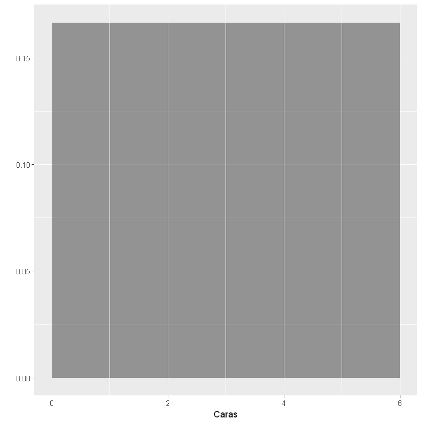

```r
library(ggplot2)

ggplot(dado) + geom_histogram(breaks = seq(0, 6), alpha = 0.6, color = "white",
                              aes(Caras,  y = (..count..)/sum(..count..))) + ylab("")

# proporciones que de los resultados que obtendríamos si lanzáramos un dado.
```

```r
muestraCaras <- sample(dado$Caras, size = 10, replace = TRUE)
dadoExp <- data.frame(Caras = muestraCaras)
dadoExp
```

| Caras |
| --- |
| 2 |
| 5 |
| 3 |
| 2 |
| 6 |
| 5 |
| 4 |
| 6 |
| 5 |
| 4 |

[figure not shown]

```r
muestraCaras <- sample(dado$Caras, size = 10, replace = TRUE)
dadoExp <- data.frame(Caras = muestraCaras)

ggplot(dadoExp, aes(x=Caras)) +
    geom_histogram(breaks = 0:6, color="white")
```

```r
data.frame(Caras = muestraCaras, DosCaras = 2*muestraCaras)
```

| Caras | DosCaras |
| --- | --- |
| 1 | 2 |
| 1 | 2 |
| 1 | 2 |
| 3 | 6 |
| 2 | 4 |
| 1 | 2 |
| 4 | 8 |
| 3 | 6 |
| 1 | 2 |
| 4 | 8 |

```r
dadoExpHist <- function(n) {
    muestraCaras <- sample(dado$Caras, size = n, replace = TRUE)
    dadoExp <- data.frame(Caras = muestraCaras)
    return(ggplot(dadoExp) + geom_histogram(breaks = seq(0, 6), alpha = 0.6, color = "white",
                              aes(Caras, y = (..count..)/sum(..count..))) + ylab(""))
}
```

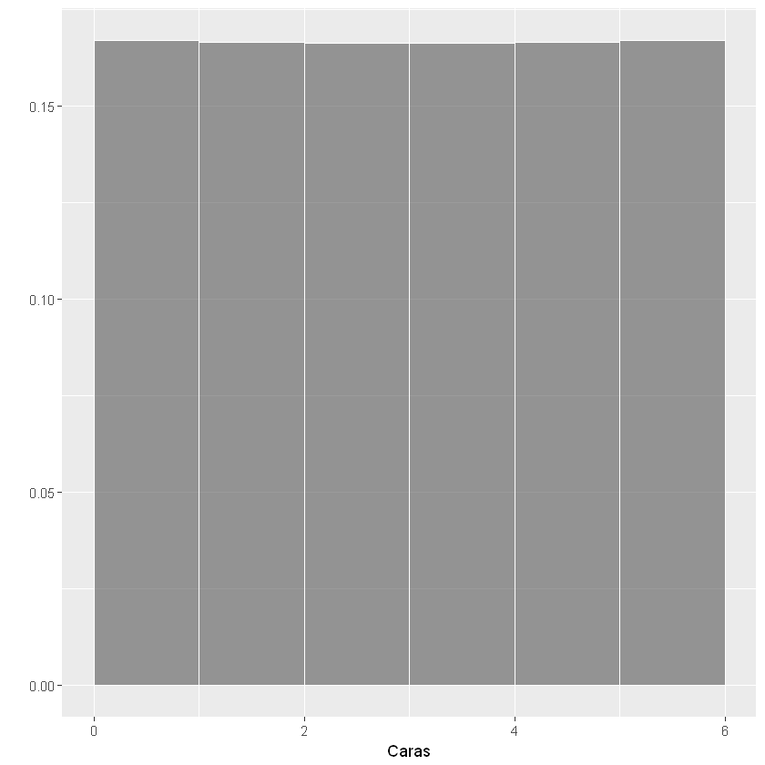

```r
dadoExpHist(1000000)
```

# Histogramas y Distribuciones

Ya sabíamos la forma del histograma! Sabes las proporciones de antemano.

Histograma es un resumen visual de la distribución.

El histograma del experimento (del muestreo) se llama histograma empírico.

```
En el mundo es igual: hay un proceso que genera un resultado pero solo observamos una parte de los resultados.
```

# Ley de los promedios (TCL CLT)

Hay una razón por la que el hsitograma empírico se parece al modelo teórico.

Si un experimento se repite en las mismas condiciones y de manera independiente, a la larga la proporción de veces que un resultado aparece se va a parecer mas y mas a la probabilidad teórica.

# Iteraciones:

for (i in seq(1,10)) { print(i) }

El cuerpo, todo lo que dentro de { }, es ejecutado para cada elemento en una secuencia.

Puede tener varias líneas. El cuerpo tiene que hacer algo.

```r
for(x in 1:10) {print(x)}
```

```
[1] 1
[1] 2
[1] 3
[1] 4
[1] 5
[1] 6
[1] 7
[1] 8
[1] 9
[1] 10
```

```r
for(i in c(3,8,10)) {print(i)}
```

```
[1] 3
[1] 8
[1] 10
```

```r
lDado <- function(n){
    sample(x = 1:n, size = 1)
}
```

```r
lDado(3)
```

1

```r
# Dos lanzamientos de dados, 1000 veces.

dosL <- data.frame(primerL=lDado(6), segundoL=lDado(6))

dosL[1, ]
```

| primerL | segundoL |
| --- | --- |
| 6 | 6 |

```r
for(i in 1:10000){
    dosL[i,] <- c(lDado(6), lDado(6))
}

head(dosL)
```

[output not shown]

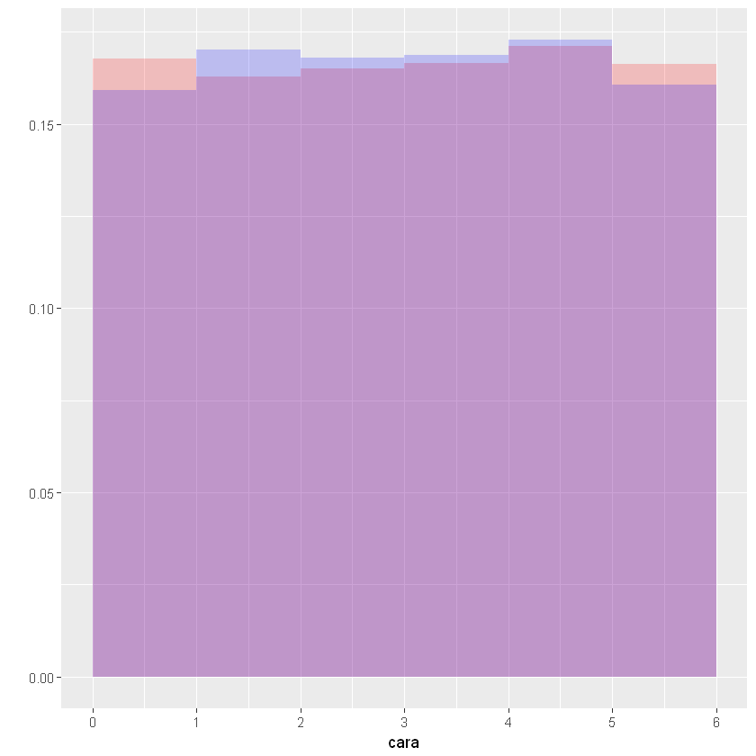

```r
# Podemos comparar dos histogramas:

ggplot(dosL) + geom_histogram(breaks = seq(0, 6), aes(x=primerL, y = (..count..)/sum(..count..)), fill = "red", alpha = 0.2) +
        geom_histogram(breaks = seq(0, 6), aes(x=segundoL, y = (..count..)/sum(..count..)), fill = "blue", alpha = 0.2) +
        ylab("") + xlab("cara") + scale_x_continuous(breaks=seq(0, 6))
```